# Regressão

Análise de Dados Ambientais · Aula 14

Prof. Dr. Luiz Diego Vidal Santos

## Roteiro da Aula

- 1 O que é Regressão?
- 2 Regressão Linear Simples
- 3 Pressupostos da Regressão
- 4 Regressão Linear Múltipla
- 5 Diagnósticos e Problemas
- 6 Variáveis Dummy
- 7 Regressão Logística Binária
- 8 Regressão Multinomial

**Objetivo:** Compreender como modelos de regressão estimam o efeito de variáveis preditoras (VIs) sobre um desfecho (VD), aplicando-os a problemas ambientais e agronômicos.

# O QUE É REGRESSÃO?

## Definição e família de modelos

**Regressão** é a técnica de análise que **quantifica** o quanto uma ou mais variáveis preditoras (VIs) explicam ou estão associadas a um desfecho (VD).

Diferentemente da correlação, a regressão tem uma **direcionalidade**: assume-se que $X$ explica $Y$.

**As três perguntas que a regressão responde:**

1 **Há associação?** (significância)

2 **Em que direção e magnitude?** (coeficientes $\beta$)

3 **Quanto da variação de Y é explicado?** ($R^2$)

[figure not shown]

Plantio direto em área agrícola

## Mapa da família de regressões

```
%%{init: {"theme": "base", "themeVariables": {"fontFamily": "Arial, sans-serif", "primaryTextColor": "#111827", "lineColor": "#111827", "edgeLabelBackground": "#FFFFFF"}}}%%
flowchart TD
    A["Tipo de<br/>variável dependente?"]:::root --> B{"VD"}:::node
  B --> B1["Contínua"]:::option
  B --> B2["Dicotômica<br/>(0/1)"]:::option
  B --> B3["Politômica<br/>nominal"]:::option
  B --> B4["Contagem"]:::option

  B1 --> C{"Quantas VIs?"}:::node
  B2 --> D["Regressão<br/>Logística Binária"]:::result
  B3 --> E["Regressão<br/>Multinomial"]:::result
  B4 --> F["Regressão<br/>de Poisson"]:::leaf

  C --> C1["1 VI"]:::option
  C --> C2["≥ 2 VIs"]:::option
  C1 --> G["Regressão Linear<br/>Simples"]:::leaf
  C2 --> H["Regressão Linear<br/>Múltipla"]:::result

    classDef root fill:#111827,color:#FFFFFF,font-weight:bold,stroke:#000000,stroke-width:2px
    classDef node fill:#FFFFFF,color:#111827,font-weight:bold,stroke:#111827,stroke-width:2px
  classDef option fill:#FEF3C7,color:#111827,font-weight:bold,stroke:#92400E,stroke-width:2px
    classDef leaf fill:#E0F2FE,color:#0F172A,font-weight:bold,stroke:#0369A1,stroke-width:2px
    classDef result fill:#1D4ED8,color:#FFFFFF,font-weight:bold,stroke:#111827,stroke-width:2px
  linkStyle default stroke:#111827,stroke-width:2px,color:#111827
```

A escolha do tipo de regressão depende **da natureza da VD** (contínua, binária, politômica, contagem) e **do número de VIs** (uma ou várias).

# REGRESSÃO LINEAR SIMPLES

## A equação fundamental

**Modelo linear simples**

$$Y = \beta_0 + \beta_x X + \varepsilon$$

| Termo | Interpretação |
| --- | --- |
| $Y$ | Variável dependente (desfecho) |
| $\beta_0$ | Intercepto (valor de Y quando X = 0) |
| $\beta_x$ | Inclinação - efeito de X sobre Y |
| $X$ | Variável independente (preditor) |
| $\varepsilon$ | Erro aleatório (variância não explicada) |

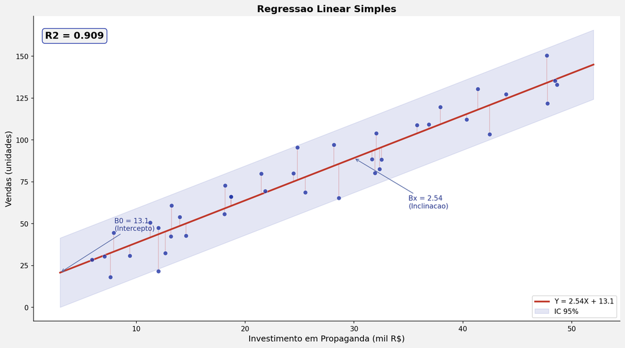

Regressão linear simples com resíduos e IC 95%

A regressão traça a **reta de melhor ajuste** que minimiza a soma dos quadrados dos resíduos (método dos mínimos quadrados ordinários - OLS).

## Exemplo: investimento em propaganda × vendas

**Cenário**

Um empresário quer saber o quanto o investimento em propaganda (VI) aumentou as vendas (VD) ao longo do mês.

- $Y$ = vendas (R$)
- $\beta_0$ = vendas esperadas **sem** propaganda
- $X$ = valor investido em propaganda
- $\beta_x$ = retorno em vendas para cada R$ 1 investido
- $\varepsilon$ = variação não explicada pelo investimento

**O que a regressão revela**

- Quanto $Y$ aumenta a cada unidade de $X$
- Quanto (em %) a presença de $X$ contribui para $Y$
- O **poder explicativo** do modelo via $R^2$:
  - $R^2 = 0{,}25$ → 25% da variância de Y explicada por X
  - $R^2 = 0{,}80$ → modelo de alta capacidade explicativa

Nenhum modelo é livre de erro: o resíduo $\varepsilon$ representa a influência de fatores externos não incluídos no modelo.

## Tipos de variáveis admitidos

**Variável dependente (VD)**

- Sempre **contínua** (intervalar ou de razão)
- Em casos especiais, pode ser ordinal com muitos níveis

**Variável independente (VI)**

- **Contínua** (intervalar/razão)
- **Ordinal**
- **Categórica dicotômica** (entra como 0/1)
- **Categórica politômica** → exige codificação **dummy** (k − 1 variáveis)

# PRESSUPOSTOS DA REGRESSÃO

## Os cinco pressupostos clássicos

**Pressupostos do modelo linear**

1 **Linearidade** - a relação entre X e Y é linear

2 **Variância não nula** das VIs

3 **Homocedasticidade** dos resíduos (variância constante)

4 **Independência** dos resíduos (sem autocorrelação)

5 **Normalidade** da distribuição dos resíduos

A violação desses pressupostos compromete a inferência: erros padrão enviesados, IC incorretos e p-valores não confiáveis.

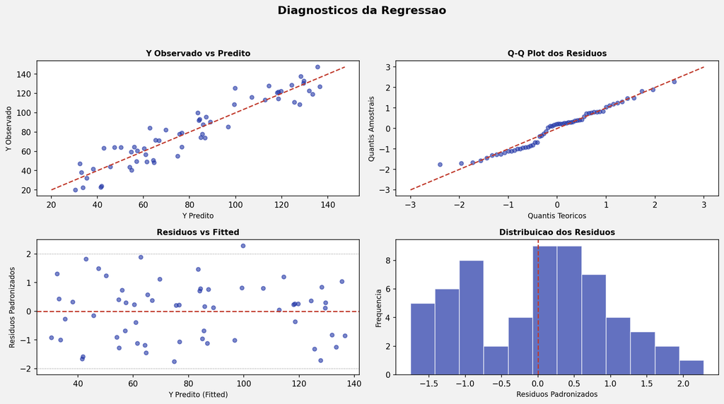

Painel de diagnósticos da regressão

**Como avaliar**

- **Linearidade:** dispersão Y vs. X
- **Homocedasticidade:** resíduos vs. ajustados
- **Normalidade:** Q-Q plot, Shapiro-Wilk
- **Independência:** Durbin-Watson

# REGRESSÃO LINEAR MÚLTIPLA

## Da simples à múltipla

**Simples**

$$Y = \beta_0 + \beta_x X + \varepsilon$$

Apenas **um** preditor.

**Múltipla**

$$Y = \beta_0 + \beta_1 X_1 + \beta_2 X_2 + \dots + \beta_n X_n + \varepsilon$$

**Vários** preditores simultâneos. Cada $\beta_i$ representa o efeito **parcial** de $X_i$ sobre $Y$, **controlando** os demais preditores.

**Exemplo aplicado - produtividade da soja**

Possíveis VIs:

- Sistema de preparo (PD / CM / CC)
- Cultura antecedente (leguminosas, gramíneas)
- Adubação verde (sim/não)
- Inoculação com *Azospirillum brasilense*
- Mecanização
- Rotação vs. monocultura

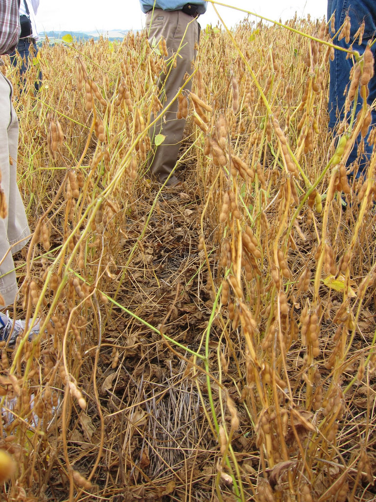

Soja em plantio direto

## Métodos de entrada das variáveis

| Método | Característica | Vantagens | Desvantagens |
| --- | --- | --- | --- |
| **Enter** (Inserir) | Todas as VIs entram simultaneamente | Simplicidade | Vulnerável à multicolinearidade; não isola o $R^2$ de cada VI |
| **Stepwise** (Por etapa) | VIs entram passo a passo pela significância de F | Modelo mais parcimonioso; isola o $R^2$ de cada VI | F sofre efeito do N; risco de **efeito supressor** |
| **Forward** (Avançar) | VIs entram pela correlação parcial com a VD | Parcimonioso; isola o $R^2$ de cada VI | Influenciado por VIs já no modelo |
| **Backward** (Retroceder) | Parte do modelo cheio e exclui VIs passo a passo | Reduz erros de inserção dos métodos forward/stepwise | - |
| **Remove** (Remover) | Exclusão **manual** das VIs para comparar modelos | Permite testar hipóteses específicas | Escolhas arbitrárias podem enviesar |

Em pesquisa aplicada, prefira **Enter** quando há **hipóteses teóricas** sobre quais VIs incluir; reserve métodos automáticos (stepwise/forward) para análises **exploratórias**.

# DIAGNÓSTICOS E PROBLEMAS

## Multicolinearidade

**Independência entre as VIs**

Quando duas ou mais VIs são fortemente correlacionadas, os coeficientes $\beta$ ficam **instáveis** e os erros padrão **inflados**.

**Diagnósticos**

- **Tolerância** = $1 - R^2_i$ (R² da VI explicada pelas demais)
  - Próxima de 1,0 → bom
- **VIF** (Variance Inflation Factor)
  - VIF > 10 → multicolinearidade séria
  - Média de VIF substancialmente > 1 → modelo tendencioso

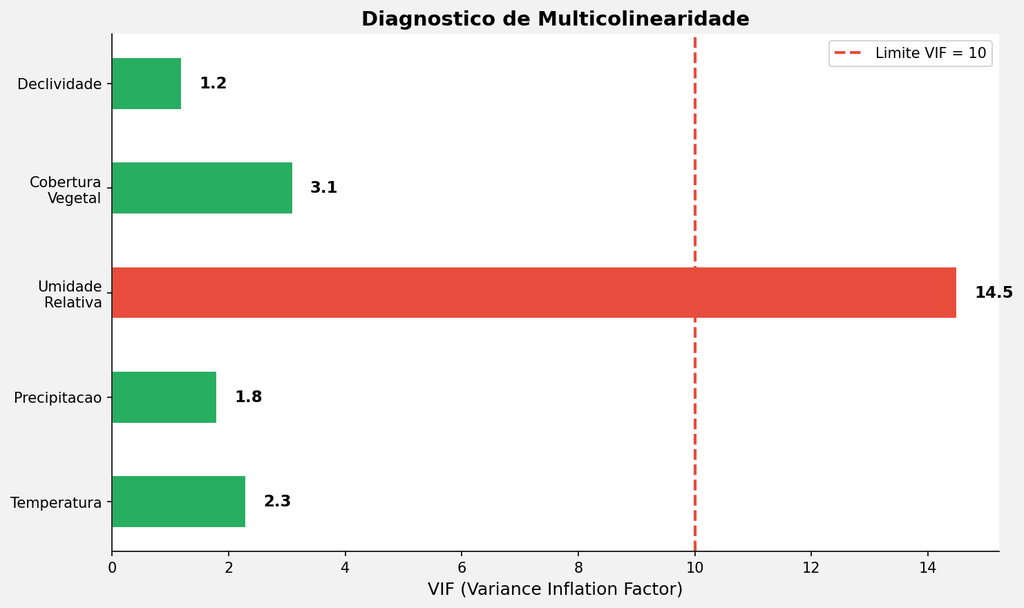

Diagnóstico de multicolinearidade (VIF)

## Independência dos resíduos

**Coeficiente de Durbin-Watson**

- Faixa aceitável: **1,5 a 2,5**
- Valores < 1,5 → autocorrelação **positiva**
- Valores > 2,5 → autocorrelação **negativa**

Especialmente crítico em **séries temporais ambientais** (ex.: monitoramento contínuo de variáveis climáticas).

Quando há autocorrelação, considere:

- Modelos de **séries temporais** (ARIMA)
- **GLS** (Generalized Least Squares)
- Inclusão de uma variável temporal como preditor

## Problemas amostrais - outliers e influência

**Resíduos padronizados (Z)**

- |Z| > 3 → **outlier**
- Se >1% da amostra com |Z| > 2,5 → problema no modelo
- Se >5% da amostra com |Z| > 2,0 → problema no modelo

**Distância de Cook**

- Mede o efeito de um único caso sobre **todo** o modelo
- Valores > 1 merecem atenção

**Distância de Mahalanobis** (referências práticas)

| N | Nº de VIs | Limite crítico |
| --- | --- | --- |
| 500 | 5 | 25 |
| 100 | 3 | 15 |
| 30 | 2 | 11 |

Outliers nem sempre devem ser excluídos: investigue se representam **erro de medição** ou **fenômeno real** (ex.: evento de chuva extrema).

## Tamanho amostral

**Regra prática (Tabachnick & Fidell, 2019)**

$$N \geq 50 + 8k$$

onde $k$ = número de variáveis preditoras.

| k (VIs) | N mínimo |
| --- | --- |
| 1 | 58 |
| 3 | 74 |
| 5 | 90 |
| 10 | 130 |

Para um cálculo **mais confiável**, use o **G*Power** definindo:

- Tamanho de efeito esperado ($f^2$)
- $\alpha = 0{,}05$
- Poder = 0,80
- Número de preditores

# VARIÁVEIS DUMMY

## Quando usar variáveis dummy

**Preditor categórico politômico**

Variáveis nominais como:

- **Estado civil:** 1 = Solteiro; 2 = Casado; 3 = Viúvo…
- **Sistema de cultivo:** 1 = CC; 2 = CM; 3 = PD

Os números **não têm sentido matemático nem ordem natural** → não podem entrar diretamente no modelo.

**Solução:** criar **k − 1** variáveis dummy (binárias 0/1), contrastando cada categoria contra uma **categoria de referência**.

A regra **k − 1** evita **multicolinearidade perfeita**.

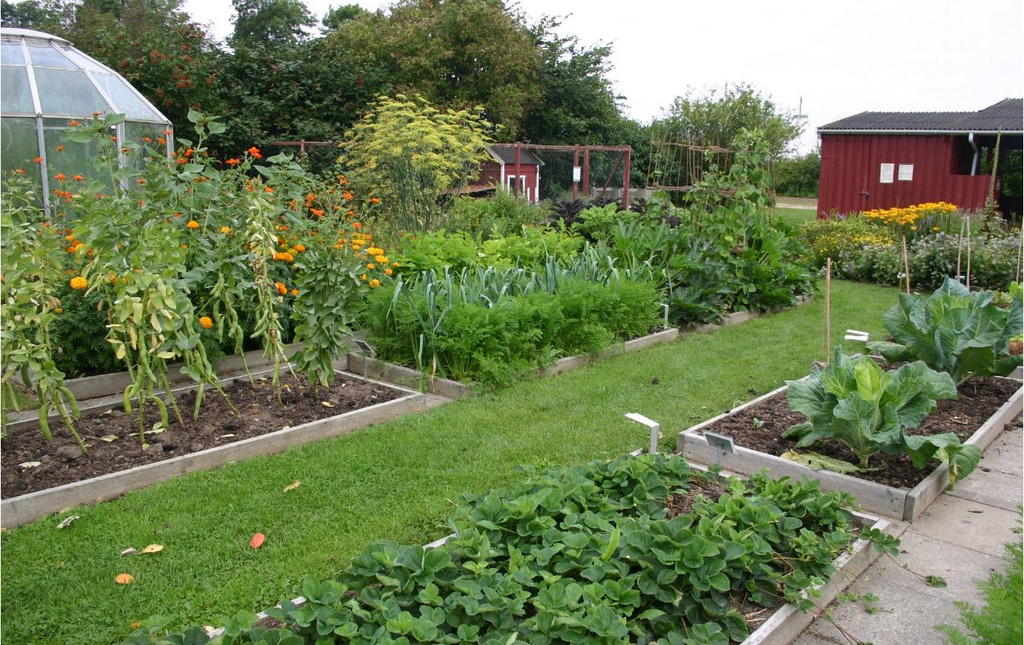

Rotação de culturas em sistema agrícola

## Exemplo: cultura antecedente

**Categorias originais**

5 níveis de cultura antecedente:

- 1 = **Controle/Mata** (referência)
- 2 = Caupi
- 3 = Milheto
- 4 = Guandu
- 5 = Crotalária

Geram **4 variáveis dummy** (k − 1 = 4).

**Tabela de codificação**

| Original | Dummy_1 | Dummy_2 | Dummy_3 | Dummy_4 |
| --- | --- | --- | --- | --- |
| Controle | 0 | 0 | 0 | 0 |
| Caupi | 1 | 0 | 0 | 0 |
| Milheto | 0 | 1 | 0 | 0 |
| Guandu | 0 | 0 | 1 | 0 |
| Crotalária | 0 | 0 | 0 | 1 |

Cada coeficiente $\beta_i$ das dummies representa a **diferença média de Y** entre aquela categoria e a categoria de referência (Controle).

# REGRESSÃO LOGÍSTICA BINÁRIA

## Quando usar regressão logística

**Objetivo**

Modelar a **probabilidade de ocorrência** de um desfecho **binário** (sim/não, 0/1) em função de uma ou mais VIs.

**Exemplos ambientais e agronômicos:**

- Presença de praga (sim/não) em função de umidade, rotação, temperatura
- Sobrevivência de mudas (vivas/mortas) em função do tipo de substrato
- Ocorrência de erosão (sim/não) em função de declividade e cobertura

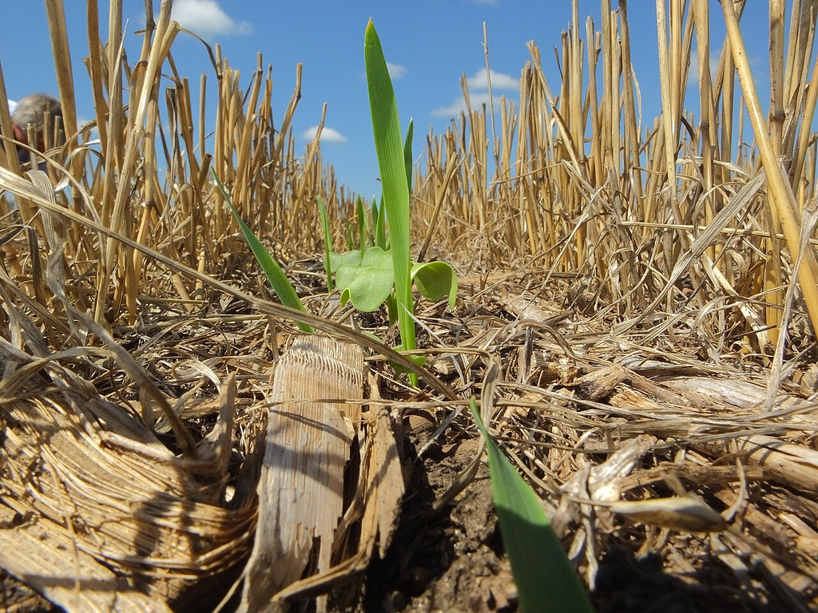

Cobertura vegetal - fator preditor de processos ambientais

## Linear vs. logística

**Regressão Linear**

- VD **contínua**
- Função: reta
- Estima **valores** de Y
- Pressupõe normalidade dos resíduos

**Regressão Logística**

- VD **binária** (0/1)
- Função: **curva sigmoide** (logit)
- Estima **probabilidades** entre 0 e 1
- Não exige normalidade dos resíduos

**Equação logística**

$$P(Y=1) = \frac{1}{1 + e^{-(\beta_0 + \beta_1 X_1 + \dots + \beta_n X_n)}}$$

Os coeficientes são interpretados como **log-odds**; sua exponencial $e^{\beta}$ fornece a **odds ratio (OR)**.

## A curva logística

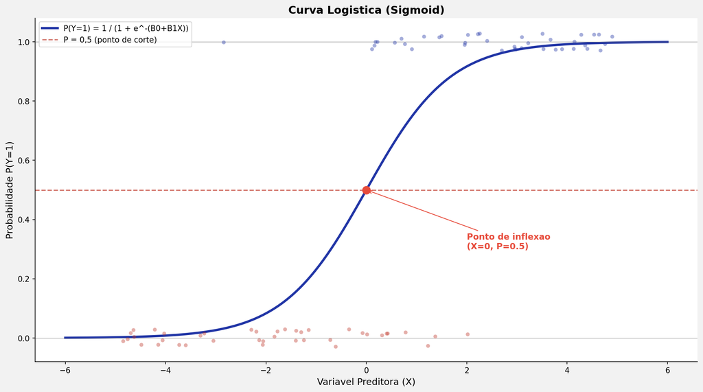

Curva logística - probabilidade × preditor

**Leitura da curva**

- Para valores baixos de X → probabilidade próxima de 0
- Para valores altos de X → probabilidade próxima de 1
- O **ponto de inflexão** (P = 0,5) define o limiar natural de classificação

**Odds ratio (OR)**

- OR > 1 → o aumento de X **aumenta** a chance do evento
- OR < 1 → o aumento de X **diminui** a chance
- OR = 1 → sem efeito

## Avaliação do modelo logístico - Curva ROC

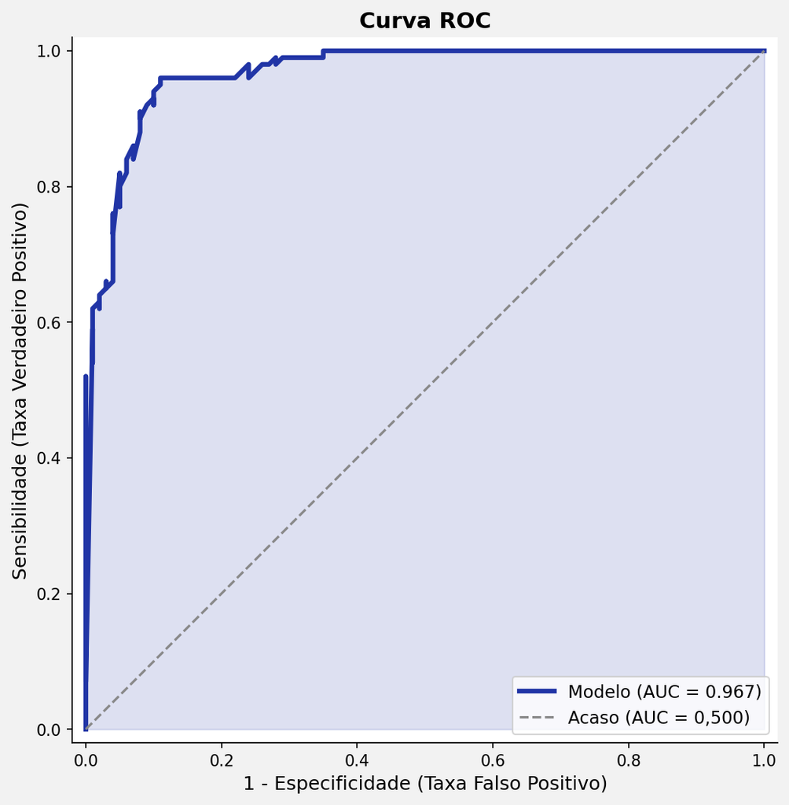

Curva ROC - sensibilidade × 1 − especificidade

**Área sob a curva (AUC)**

| AUC | Interpretação |
| --- | --- |
| 0,50 | Modelo aleatório |
| 0,60-0,70 | Discriminação fraca |
| 0,70-0,80 | Aceitável |
| 0,80-0,90 | Excelente |
| > 0,90 | Excepcional |

A curva ROC mostra o **trade-off** entre sensibilidade (verdadeiros positivos) e 1 − especificidade (falsos positivos) ao variar o limiar de decisão.

# REGRESSÃO MULTINOMIAL

## Estendendo a logística

**Quando a VD é politômica**

A **regressão multinomial** (ou polinomial) é usada quando a VD tem **≥ 3 categorias nominais** (sem ordem natural).

**Exemplos:**

- Tipo de solo dominante (Argissolo, Latossolo, Neossolo)
- Classe de uso da terra (mata, pasto, cultivo, urbano)
- Estado fitossanitário (saudável, leve, severo)

**Como funciona**

- Escolhe-se uma **categoria de referência**
- O modelo estima **k − 1 equações logísticas** simultâneas, cada uma contrastando uma categoria contra a referência
- Resultados em **odds ratio**, interpretados em relação à referência

Pressupostos análogos à logística binária + **independência das alternativas irrelevantes (IIA)**: a razão entre quaisquer duas alternativas não deve depender das demais opções disponíveis.

## Resumo - escolhendo o modelo de regressão certo

```
%%{init: {"theme": "base", "themeVariables": {"fontFamily": "Arial, sans-serif", "primaryTextColor": "#111827", "lineColor": "#111827", "edgeLabelBackground": "#FFFFFF"}}}%%
flowchart LR
    A["Natureza da VD?"]:::root --> B["Contínua"]:::node
    A --> C["Dicotômica"]:::node
    A --> D["Politômica<br/>nominal"]:::node
    A --> E["Contagem"]:::node

  class B,C,D,E option

    B --> F{"Quantas VIs?"}:::node
    F --> |"1"| G["Regressão Linear<br/>Simples"]:::leaf
    F --> |"≥ 2"| H["Regressão Linear<br/>Múltipla"]:::result

    C --> I["Regressão<br/>Logística Binária"]:::result
    D --> J["Regressão<br/>Multinomial"]:::result
    E --> K["Regressão<br/>de Poisson"]:::leaf

    classDef root fill:#111827,color:#FFFFFF,font-weight:bold,stroke:#000000,stroke-width:2px
    classDef node fill:#FFFFFF,color:#111827,font-weight:bold,stroke:#111827,stroke-width:2px
    classDef option fill:#FEF3C7,color:#111827,font-weight:bold,stroke:#92400E,stroke-width:2px
    classDef leaf fill:#E0F2FE,color:#0F172A,font-weight:bold,stroke:#0369A1,stroke-width:2px
    classDef result fill:#1D4ED8,color:#FFFFFF,font-weight:bold,stroke:#111827,stroke-width:2px
    linkStyle default stroke:#111827,stroke-width:2px,color:#111827
```

**Roteiro decisório:**

1 Identifique a **natureza da VD** (contínua, binária, politômica, contagem)

2 Conte o número de **VIs** e seus tipos (contínuas, categóricas → dummy)

3 Escolha o **método de entrada** (Enter para hipóteses, stepwise para exploração)

4 **Verifique pressupostos** e **diagnósticos** (VIF, Durbin-Watson, Cook, ROC)

Obrigado!

Luiz Diego Vidal Santos

Universidade Estadual de Feira de Santana (UEFS)